# Part_II_slide_deck_template slides

## Dataset Overview

The Ford GoBike System Data is a set of informations about individual rides made in a bike-sharing system covering the greater San Francisco Bay area.

## Distribution of member gender

We can see that member gender is higly dominated by Male.

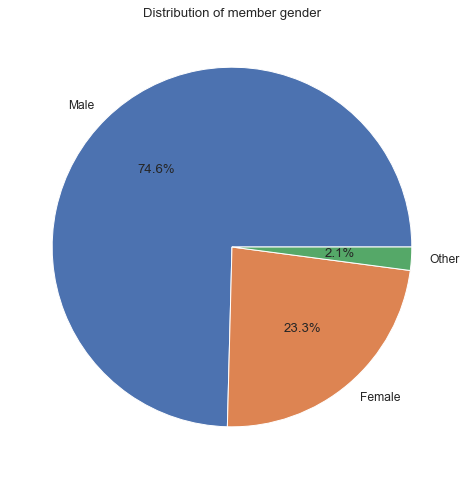

## Distributiion of user type

User type is hightly dominated by subscribers

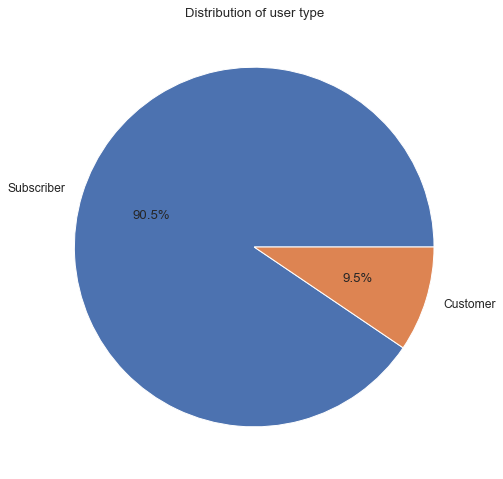

## Distribution of start periode of the day

Bike trips mostly start in afternoon

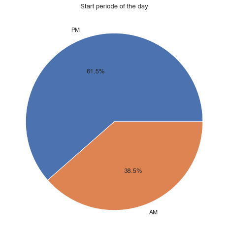

## Distribution of days in the week

Most of the bike trip start on tuesday, wednesday and thursday.

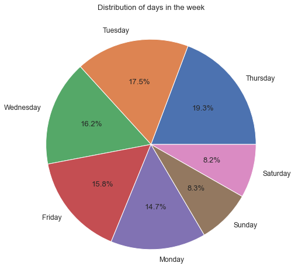

## Influence of age on duration

Teenagers and adults ride longuer than elders

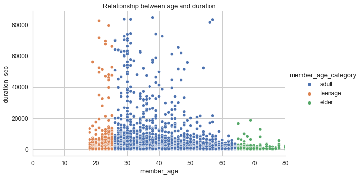

## Proportions of bike share for all trip per member age category

The huge majority of members are against bike share for all the trip.

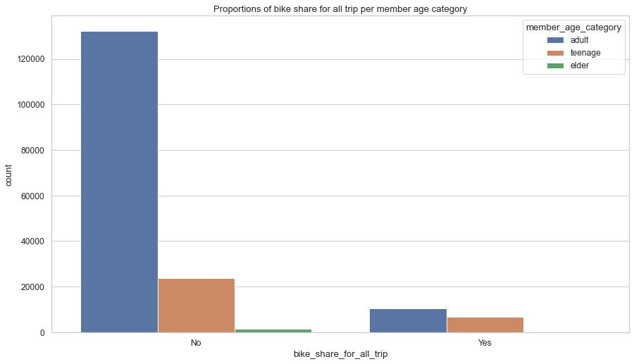